# Домашнее задание по визуализации данных №1

Олег Тарасов

28.09.2024

## Столбчатые диаграммы

### 1. Распределение числа студентов по курсу обучения

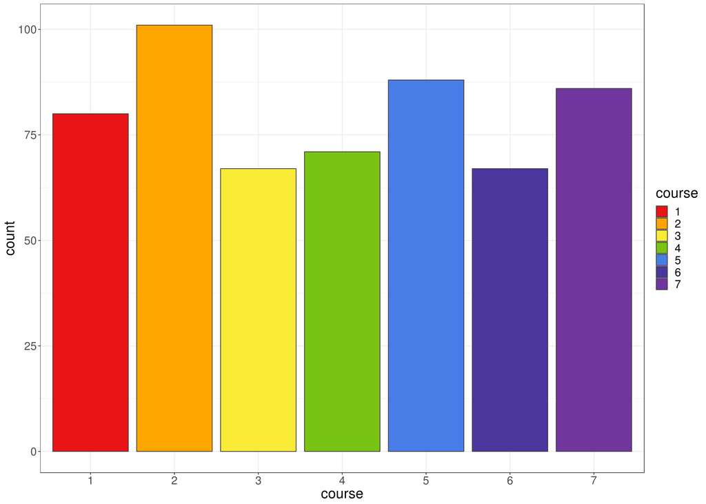

### 2. Распределение числа студентов по факультету

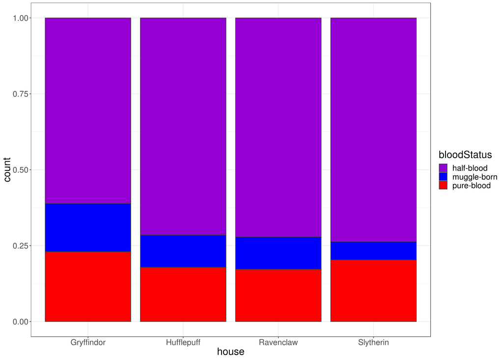

Видно, что среди всех факультетов самая большая доля как чистокровных, так и маглорожденных студентов — на Гриффиндоре, а Слизерин отличается наименьшей долей маглорожденных и наибольшей долей полукровок. Пуффендуй и Когтевран почти не отличаются в распределениях студентов по происхождению, занимая промежуточное между Гриффиндором и Слизерином положение по долям маглорожденных и полукровок и имея наименьшие доли чистокровных студентов.

### 3.

Если убрать из рассмотрения студентов-полукровок, то график приобретает следующий вид:

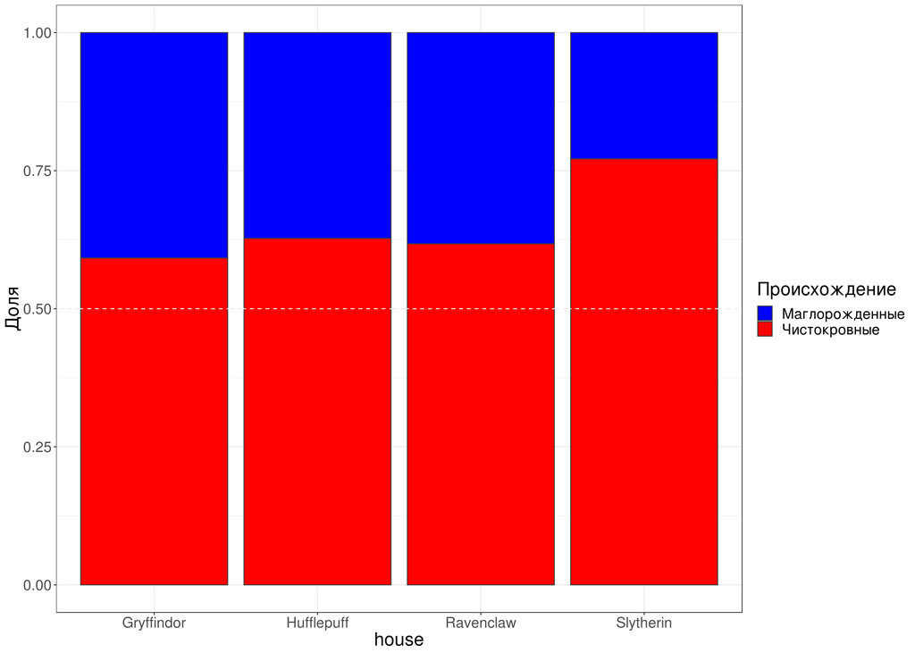

## Боксплоты

### 1. Распределение баллов, заработанных студентами на 3-й неделе обучения, по факультетам

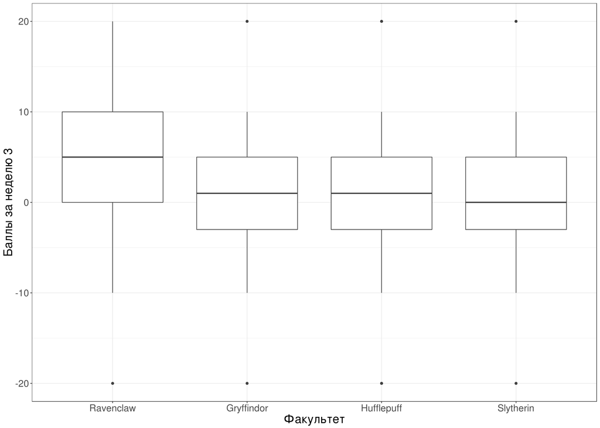

### 2.

Следующий график отображает то же самое распределение с учетом происхождения студентов:

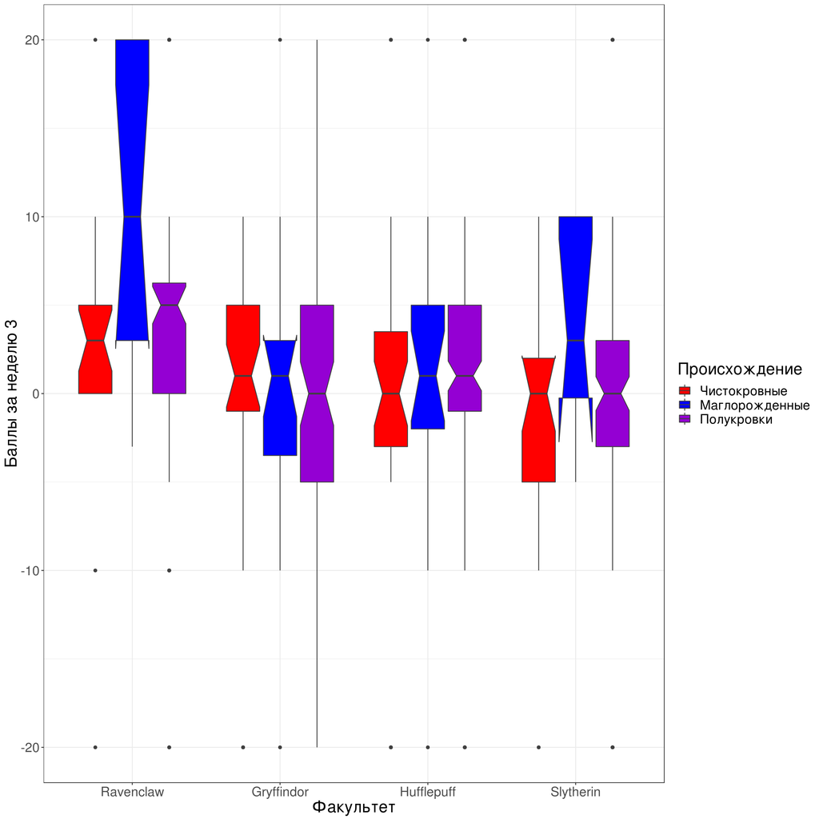

### 3.

Можно также убрать отображение выбросов и добавить разброс точек:

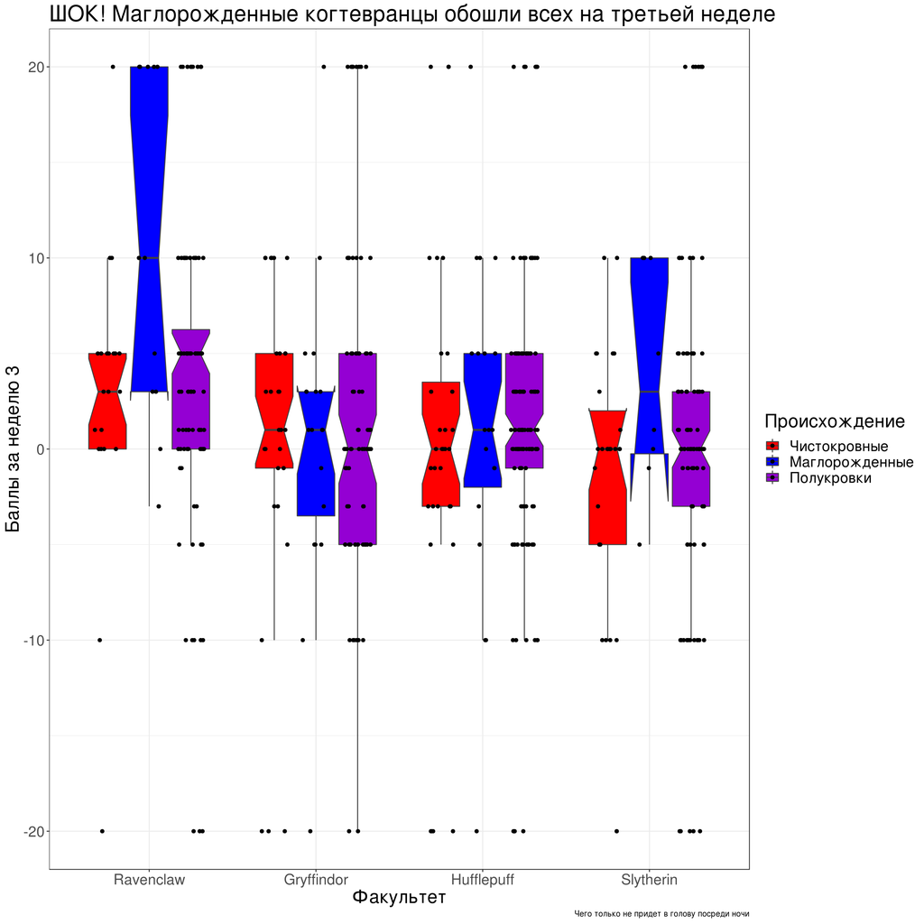

## Разное

### 1. “Леденцовый график”

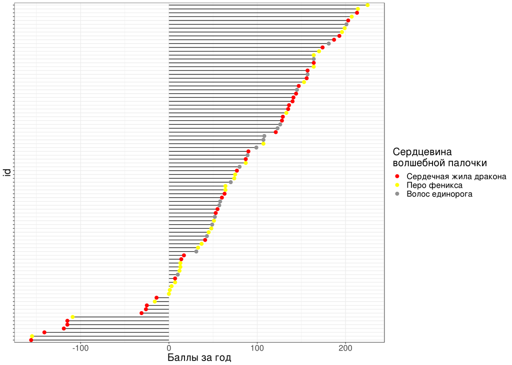

### 2. Распределение баллов по астрономии

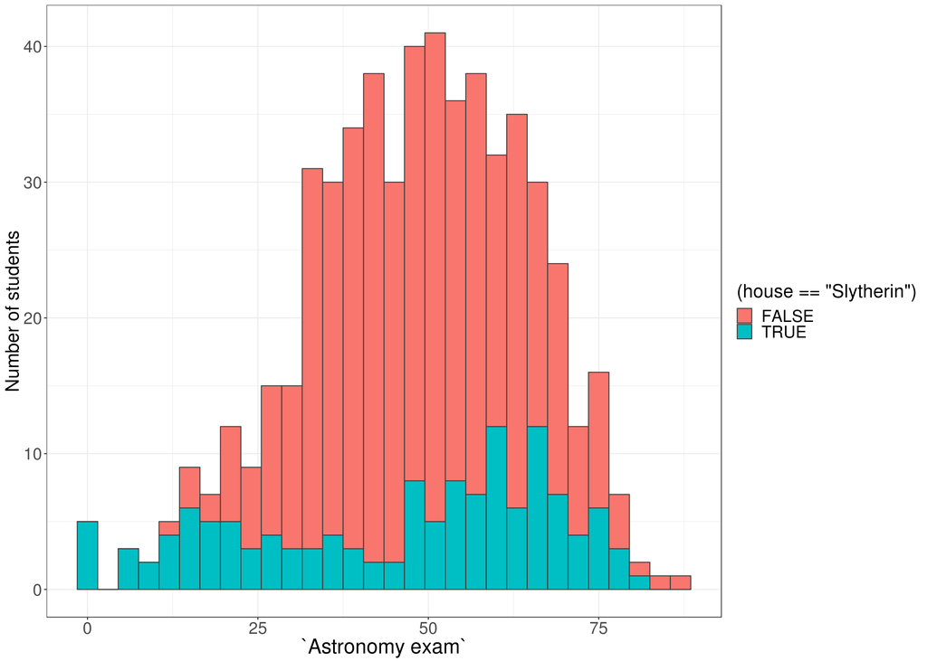

### 3. Модификация theme_custom

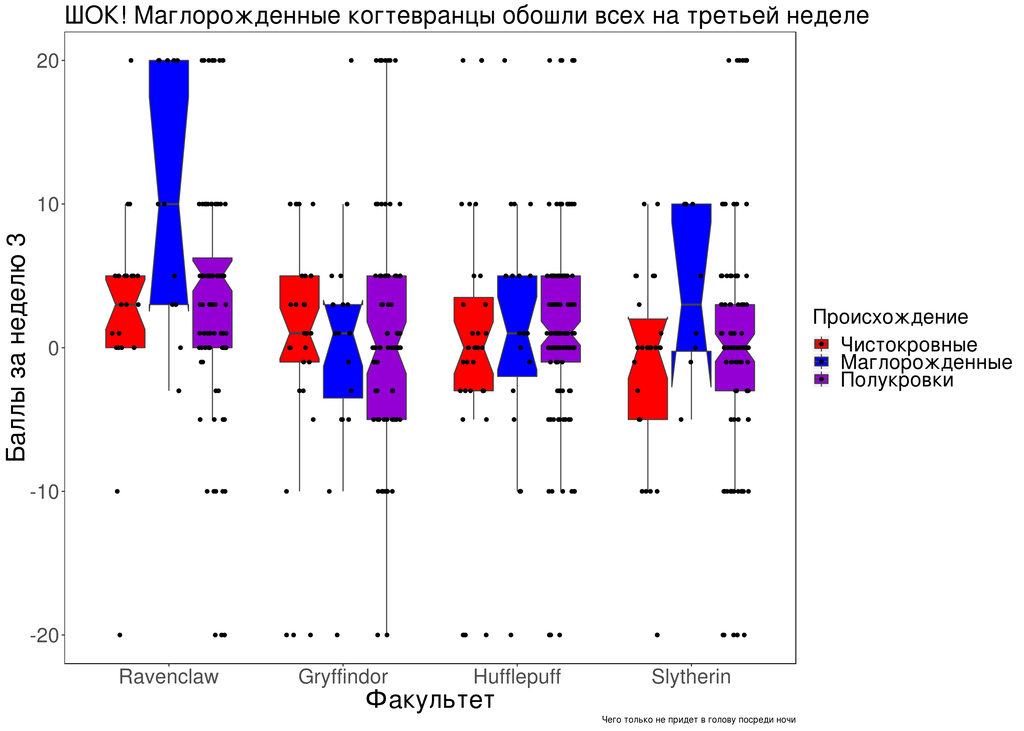

## Фасетирование

### 1.

Фасетирование сделает иллюстрацию более информативной, если графики будут располагаться так, чтобы по общей для них оси оказалась отложена переменная, по которой мы хотим провести сравнение (т.е. продемонстировать сходство или различие).

Соответственно, вертикальные гистограммы обычно лучше фасетировать по строкам (а горизонтальные — по столбцам), т.к. в этом случае будут лучше видны изменения в форме и положении распределения. Однако можно представить себе ситуацию, в которой гистограммы будет уместнее фасетировать по столбцам: например, если диапазон значений интересующей нас величины в нескольких группах одинаков, но мы хотим проиллюстрировать существенные различия в частотах на определенных интервалах. “Скрипичные диаграммы”, наоборот, будут лучше смотреться, если их фасетировать по столбцам (для вертикальных диаграмм; для горизонтальных — по строкам).

### 2.

Но если нашим приоритетом является компактность общей картинки, то тогда описанным выше принципом придется пренебречь.

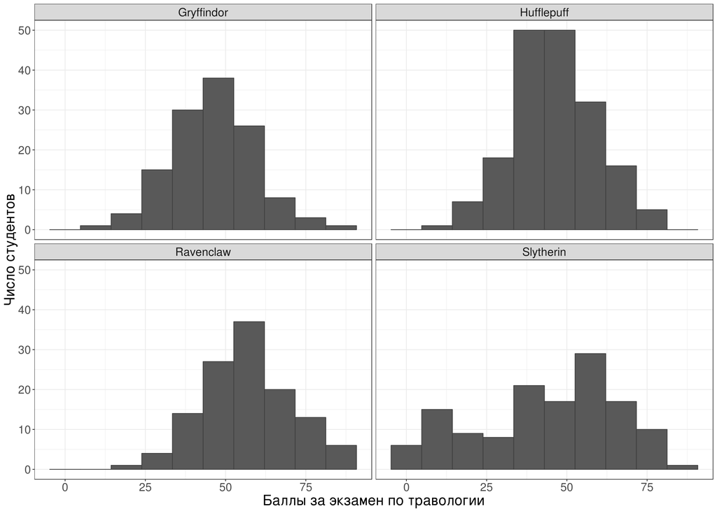

### 3. Оценки по ЗТИ и травологии

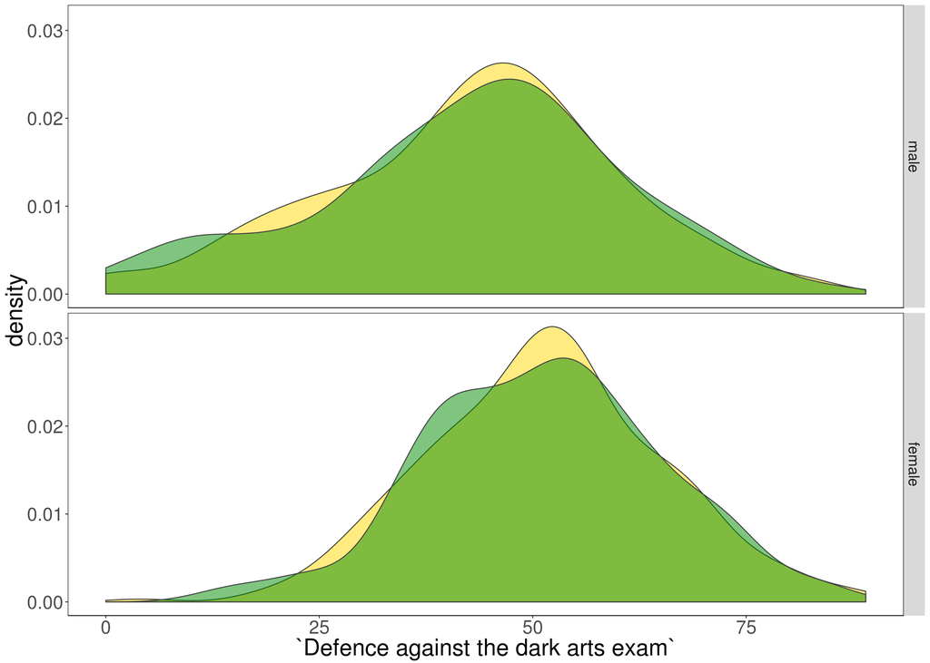